# Entendendo as dados

Vitória

2023-03-14

## Resumo dos capítulos anteriores

Para identificar os SNPs clinais, corri um glm para cada SNP e extraí o coeficiente de inclinação e os p-valores. Mas, quando fiz isso com nos SNPs que foram chamados com frequência mínima de 0.5%, houve um pico de p-valores muito altos. Esse pico pode ter sido causado por um excesso de SNPs raros (com baixíssima frequência) que aparecem em algumas populações. Como todos os SNPs foram chamados juntos, se esse SNP raro estiver presente em apenas uma população, as populações do outro período terão todas as frequência igual a zero. Esse aglomerado de zeros faria com que o p-valor fosse muito alto e isso explicaria o pico de p-valores altos. Quando chamei os SNPs pedindo por uma frequência mínima de 1%, o número de SNPs com p-valores altos diminuiu consideravelmente. Esse documento apresenta algumas informações que podem ajudar a entender melhor os SNPs que foram chamados em cada situação.

## Correlação de p-valores

Fiz a correlação entre os p-valores dos SNPs em 1997 e em 2009/2010 (lembrando que os mesmos SNPs foram analisados nos dois períodos). Fiz o mesmo com os coeficientes.

### primeiro call

```r
cor.test(merged_cov10$p_value_97, merged_cov10$p_value_0910, method = "pearson")
```

```
##
##  Pearson's product-moment correlation
##
## data:  merged_cov10$p_value_97 and merged_cov10$p_value_0910
## t = 40.57, df = 2187222, p-value < 2.2e-16
## alternative hypothesis: true correlation is not equal to 0
## 95 percent confidence interval:
##  0.02609718 0.02874571
## sample estimates:
##        cor
## 0.02742149
```

```r
cor.test(merged_cov10$coefficients_97, merged_cov10$coefficients_0910, method = "pearson")
```

```
##
##  Pearson's product-moment correlation
##
## data:  merged_cov10$coefficients_97 and merged_cov10$coefficients_0910
## t = 42.473, df = 2187222, p-value < 2.2e-16
## alternative hypothesis: true correlation is not equal to 0
## 95 percent confidence interval:
##  0.02738267 0.03003101
## sample estimates:
##        cor
## 0.02870689
```

Também corri uma regressão:

```r
p_value_lm <- lm(p_value_97 ~ p_value_0910, data = merged_cov10)
summary(p_value_lm)
```

```
##
## Call:
## lm(formula = p_value_97 ~ p_value_0910, data = merged_cov10)
##
## Residuals:
##      Min       1Q   Median       3Q      Max
## -0.49108 -0.33562 -0.03525  0.33080  0.54051
##
## Coefficients:
##               Estimate Std. Error t value Pr(>|t|)
## (Intercept)  0.4594937  0.0004197 1094.94   <2e-16 ***
## p_value_0910 0.0315838  0.0007785   40.57   <2e-16 ***
## ---
## Signif. codes:  0 '***' 0.001 '**' 0.01 '*' 0.05 '.' 0.1 ' ' 1
##
## Residual standard error: 0.3506 on 2187222 degrees of freedom
## Multiple R-squared:  0.0007519,  Adjusted R-squared:  0.0007515
## F-statistic:  1646 on 1 and 2187222 DF,  p-value: < 2.2e-16
```

```r
coefficient_lm <- lm(coefficients_97 ~ coefficients_0910, data = merged_cov10)
summary(coefficient_lm)
```

```
##
## Call:
## lm(formula = coefficients_97 ~ coefficients_0910, data = merged_cov10)
##
## Residuals:
##      Min       1Q   Median       3Q      Max
## -22.8587  -0.2854  -0.2289  -0.1635  23.3419
##
## Coefficients:
##                   Estimate Std. Error t value Pr(>|t|)
## (Intercept)       0.229665   0.001474  155.85   <2e-16 ***
## coefficients_0910 0.048076   0.001132   42.47   <2e-16 ***
## ---
## Signif. codes:  0 '***' 0.001 '**' 0.01 '*' 0.05 '.' 0.1 ' ' 1
##
## Residual standard error: 2.173 on 2187222 degrees of freedom
## Multiple R-squared:  0.0008241,  Adjusted R-squared:  0.0008236
## F-statistic:  1804 on 1 and 2187222 DF,  p-value: < 2.2e-16
```

Mas o interessante foi quando tentei plotar os p-valores de um período em relação ao outro período.

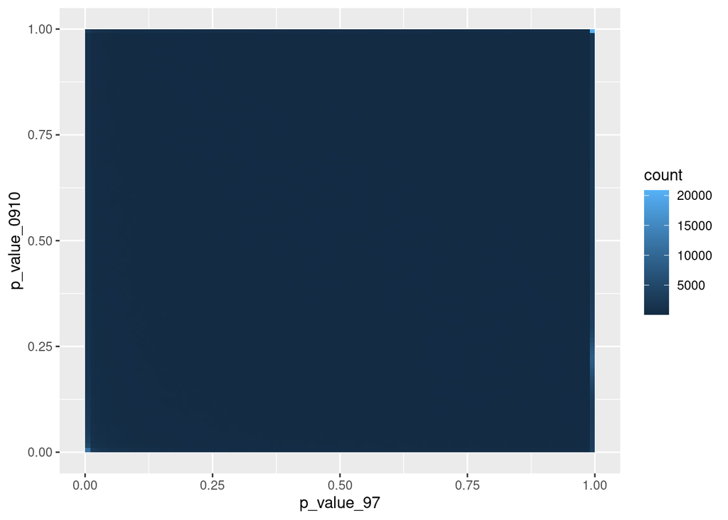

```r
ggplot(merged_cov10) +
  geom_bin2d(aes(x = p_value_97, y = p_value_0910), binwidth = c(0.01, 0.01))
```

Dá para ver que, no geral, o p-valor do SNP de uma época tem pouco a dizer sobre o p-valor do mesmo SNP na outra época, com exceção dos SNPs com p-valores muito baixos ou dos SNPs com p-valores muito altos. Se eu der um zoom, fica mais caro como os p-valores altos se comportam:

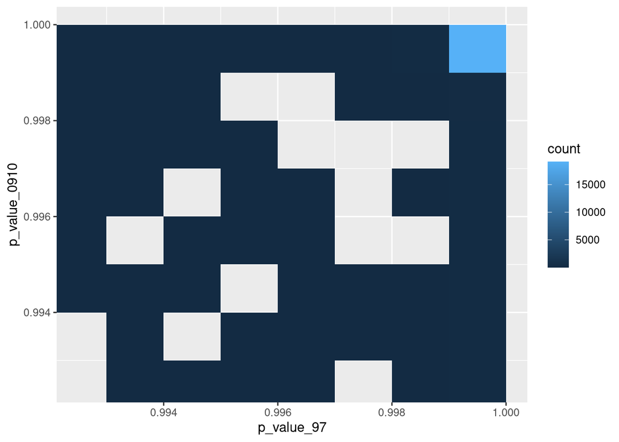

```r
ggplot(merged_cov10) +
  geom_bin2d(aes(x = p_value_97, y = p_value_0910),
             binwidth = c(0.001, 0.001)) +
  coord_cartesian(xlim = c(0.9925, 1), ylim = c(0.9925, 1))
```

Tem muitos p-valores **muito** altos que são muito altos nos dois períodos.

O mesmo gráfico para os coeficientes:

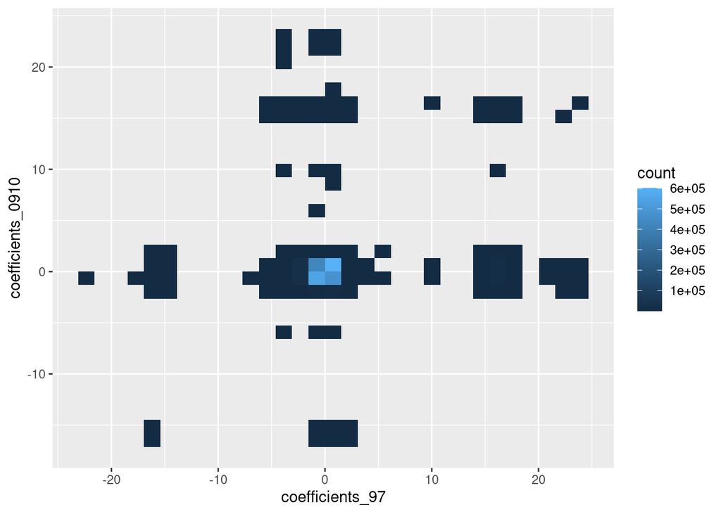

```r
merged_cov10 %>%
  ggplot() +
  geom_bin2d(aes(x = coefficients_97, y = coefficients_0910))
```

### segundo call

Até aqui tudo foi feito com base no primeiro call (com frequência mínima de 0.5%, cobertura mínima de 10). Mas eu também fiz o mesmo com o segundo call (min-freq de 1% e min-cov de 15).

```r
cor.test(merged_cov15$p_value_97, merged_cov15$p_value_0910, method = "pearson")
```

```
##
##  Pearson's product-moment correlation
##
## data:  merged_cov15$p_value_97 and merged_cov15$p_value_0910
## t = 25.429, df = 1017465, p-value < 2.2e-16
## alternative hypothesis: true correlation is not equal to 0
## 95 percent confidence interval:
##  0.02325981 0.02714348
## sample estimates:
##        cor
## 0.02520174
```

```r
cor.test(merged_cov15$coefficients_97, merged_cov15$coefficients_0910, method = "pearson")
```

```
##
##  Pearson's product-moment correlation
##
## data:  merged_cov15$coefficients_97 and merged_cov15$coefficients_0910
## t = 13.662, df = 1017465, p-value < 2.2e-16
## alternative hypothesis: true correlation is not equal to 0
## 95 percent confidence interval:
##  0.01160025 0.01548568
## sample estimates:
##        cor
## 0.01354301
```

```r
p_value_lm <- lm(p_value_97 ~ p_value_0910,
                 data = merged_cov15)
summary(p_value_lm)
```

```
##
## Call:
## lm(formula = p_value_97 ~ p_value_0910, data = merged_cov15)
##
## Residuals:
##      Min       1Q   Median       3Q      Max
## -0.40342 -0.30226 -0.06902  0.26709  0.62355
##
## Coefficients:
##               Estimate Std. Error t value Pr(>|t|)
## (Intercept)  0.3764525  0.0005517  682.30   <2e-16 ***
## p_value_0910 0.0269690  0.0010606   25.43   <2e-16 ***
## ---
## Signif. codes:  0 '***' 0.001 '**' 0.01 '*' 0.05 '.' 0.1 ' ' 1
##
## Residual standard error: 0.3231 on 1017465 degrees of freedom
## Multiple R-squared:  0.0006351,  Adjusted R-squared:  0.0006341
## F-statistic: 646.6 on 1 and 1017465 DF,  p-value: < 2.2e-16
```

```r
coefficient_lm <- lm(coefficients_97 ~ coefficients_0910,
                     data = merged_cov15)
summary(coefficient_lm)
```

```
##
## Call:
## lm(formula = coefficients_97 ~ coefficients_0910, data = merged_cov15)
##
## Residuals:
##      Min       1Q   Median       3Q      Max
## -17.3241  -0.1769  -0.1193  -0.0587  17.3667
##
## Coefficients:
##                   Estimate Std. Error t value Pr(>|t|)
## (Intercept)       0.118265   0.001518   77.91   <2e-16 ***
## coefficients_0910 0.038350   0.002807   13.66   <2e-16 ***
## ---
## Signif. codes:  0 '***' 0.001 '**' 0.01 '*' 0.05 '.' 0.1 ' ' 1
##
## Residual standard error: 1.53 on 1017465 degrees of freedom
## Multiple R-squared:  0.0001834,  Adjusted R-squared:  0.0001824
## F-statistic: 186.7 on 1 and 1017465 DF,  p-value: < 2.2e-16
```

Parece que os p-valores baixos ainda ocorrem juntos, mas não os altos:

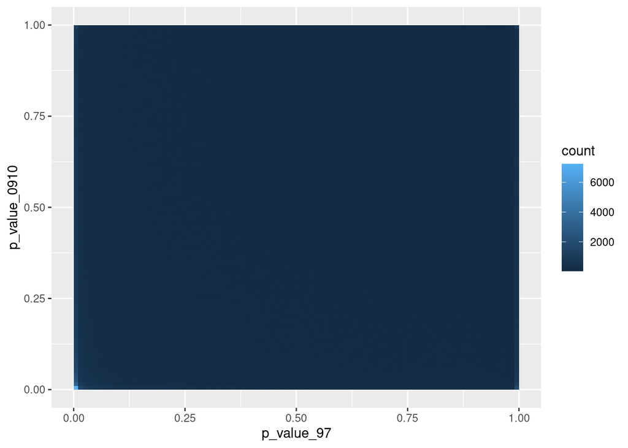

```r
ggplot(merged_cov15) +
  geom_bin2d(aes(x = p_value_97, y = p_value_0910), binwidth = c(0.01, 0.01))
```

Se eu de um zoom nos p-valores altos, ainda existe a sobreposição, mas não tão alta:

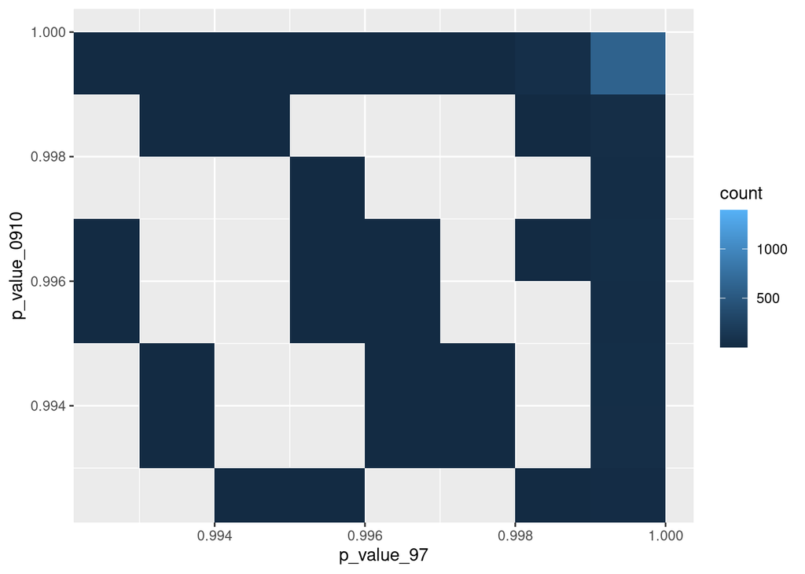

```r
ggplot(merged_cov15) +
  geom_bin2d(aes(x = p_value_97, y = p_value_0910),
             binwidth =  c(0.001, 0.001)) +
  coord_cartesian(xlim = c(0.9925, 1), ylim = c(0.9925, 1))
```

Os coeficientes continuam da mesma forma:

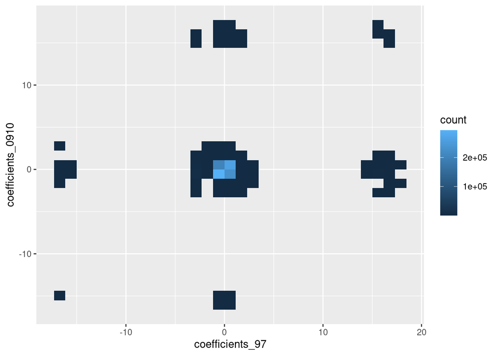

```r
merged_cov15 %>%
  ggplot() +
  geom_bin2d(aes(x = coefficients_97, y = coefficients_0910))
```

## frequência média

Podemos olhar para a distribuição das médias das frequências para ver se realmente existem muitos SNPs muito raros.

### primeiro call

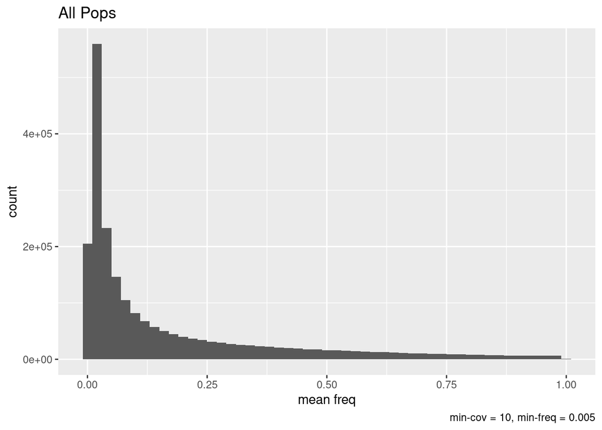

Se olharmos para a distribuição da média dos períodos separadamente:

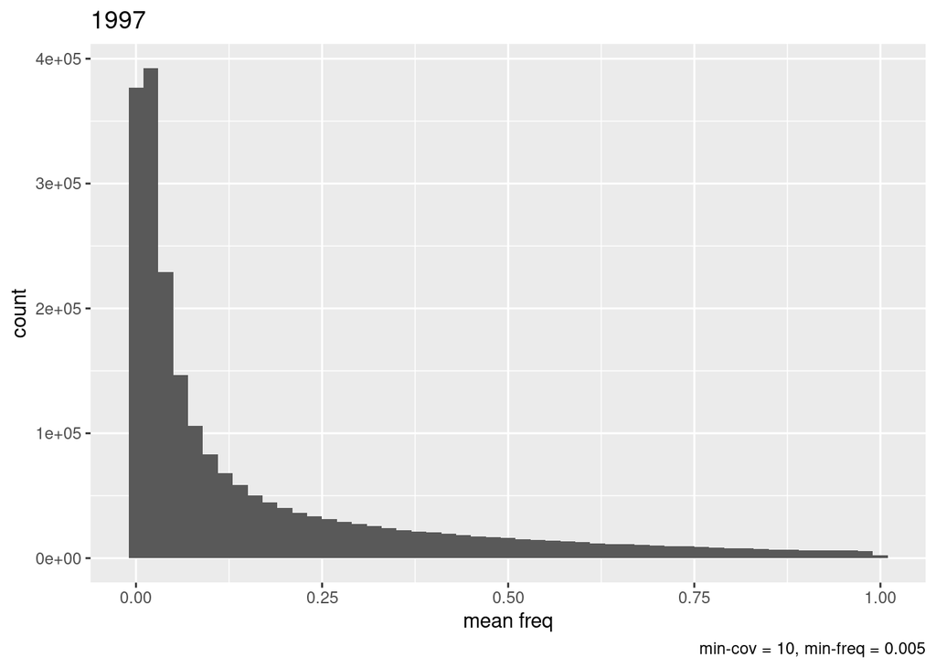

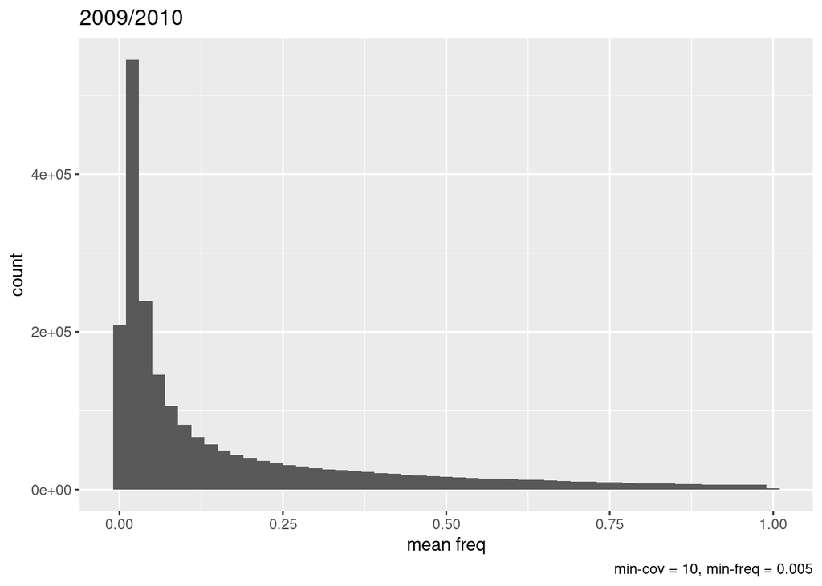

A distribuição da frequência média considerando todas as populações e considerando apenas as populações de 2009/2010 ficou praticamente idêntica. Mas é possível ver um acúmulo de médias baixas quando olhamos só para as populações de 1997.

### segundo call

Ao seguir os mesmos passos para a segunda chamada de SNPs, temos:

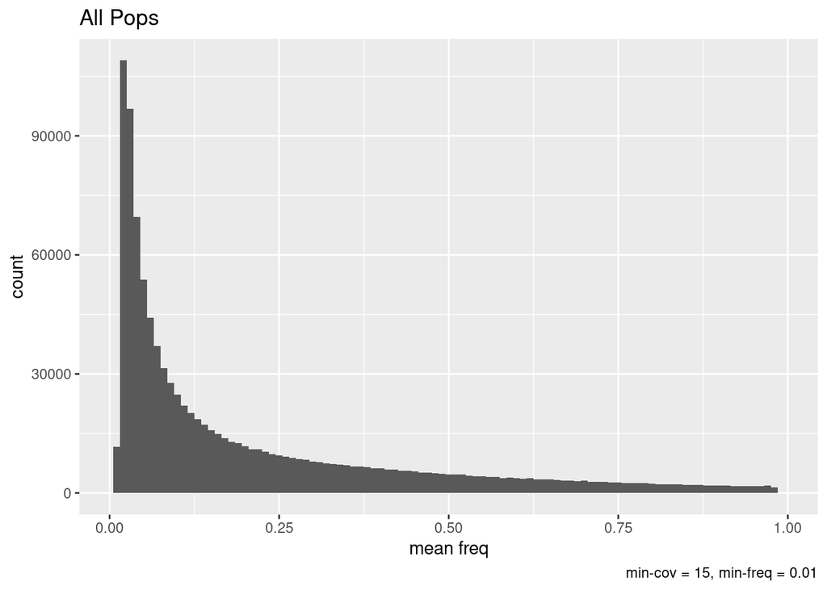

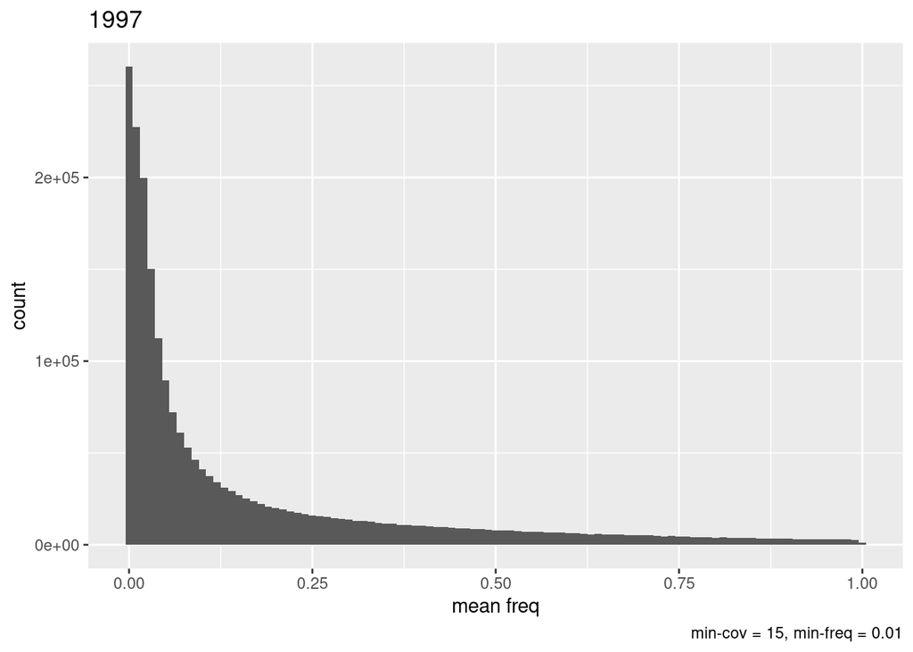

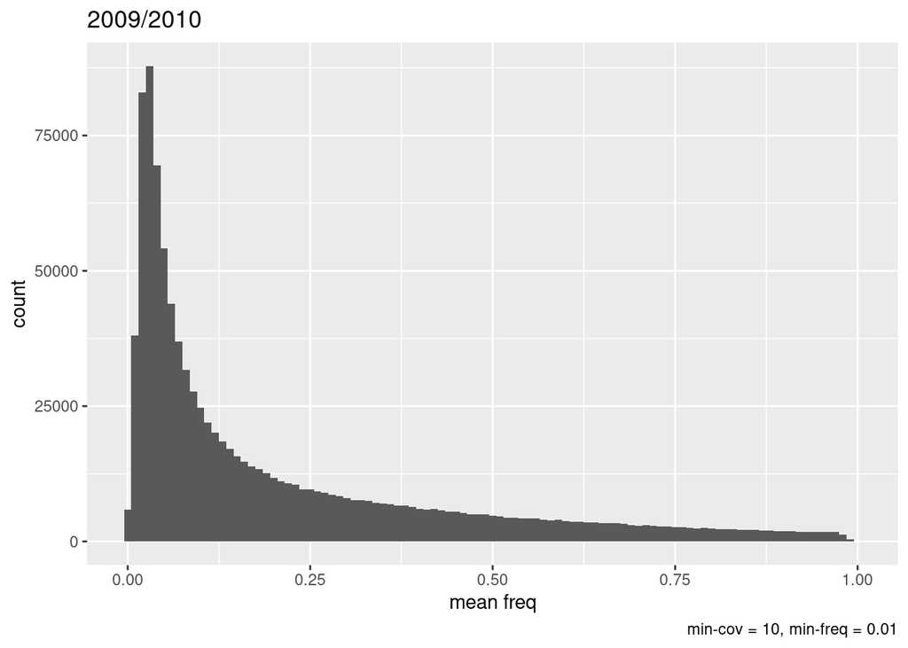

## PCA

Para fazer o PCA das populações precisei excluir a população ESC97 (aquela com o sequenciamento de baixa qualidade). Isso foi necessário porque muitos SNPs não foram chamados nessa população por ela não ter passado nos filtros de qualidade, e a função que faz o PCA no R não admite NAs. Lembrando que, pelas especificações que dei para o PoolSNP, isso só poderia acontecer com uma população _ se mais de uma população não atender às exigências de qualidade, o SNP não é chamado para nenhuma população.

### primeiro call

A variação estava relativamente bem distribuida entre os PCs:

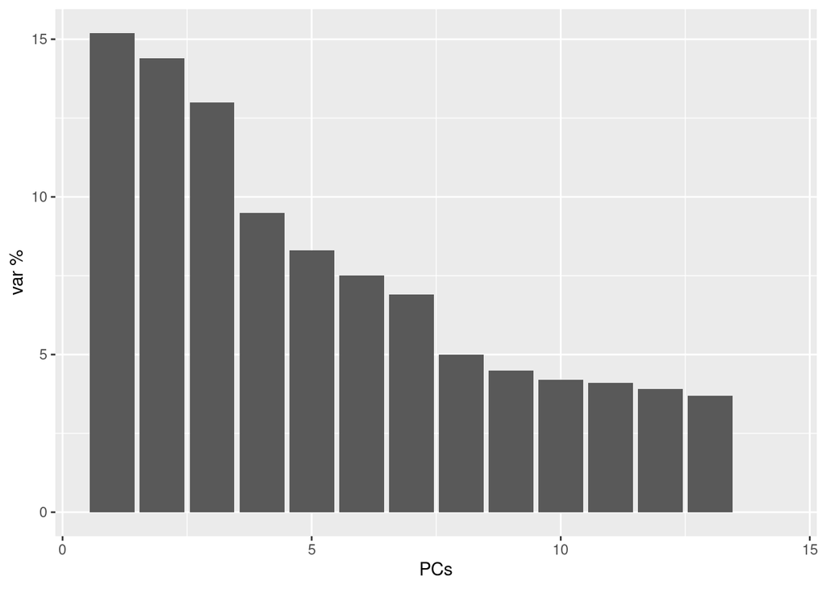

Parece que separa um pouco pela a latitude, mas as amostras CMD97B e MFL97 são muito diferentes das demais independente da latitude.

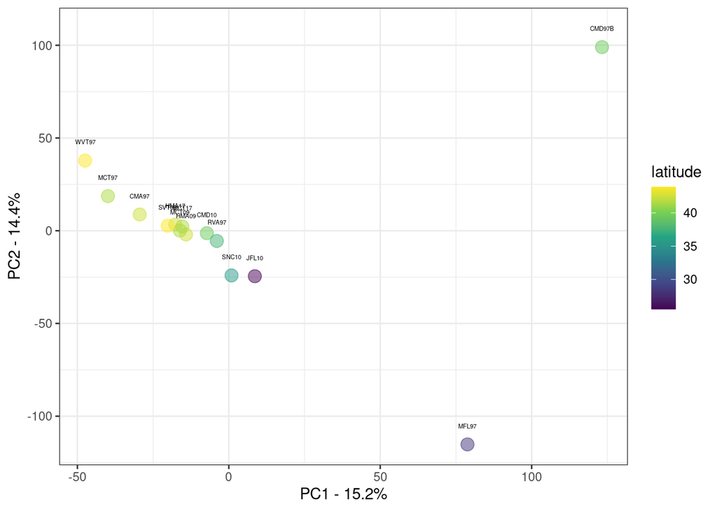

Se eu plotar o PC3 e o PC4:

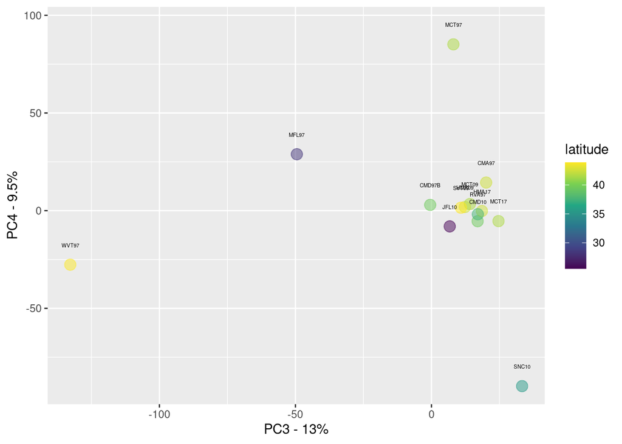

Como a cobertura de CMD97B também não está muito boa e já combinamos de refazer o sequenciamento resolvi refazer o PCA sem ela:

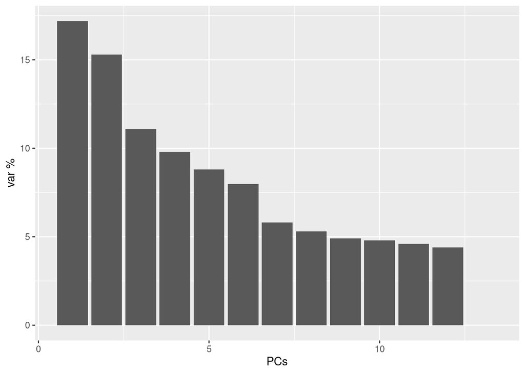

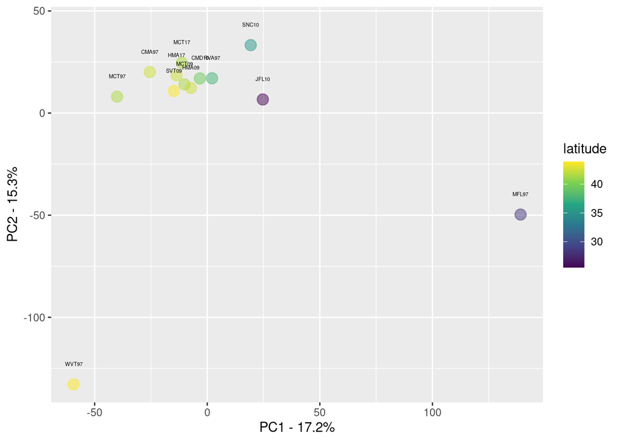

Também fiz o PCA das populações de 1997 e de 2009/2010 separadamente:

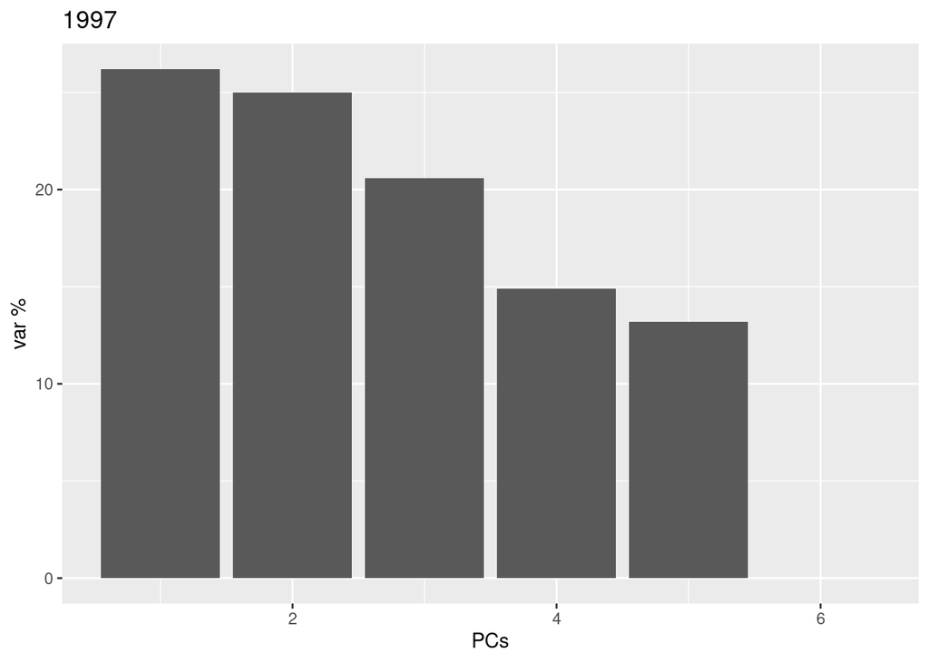

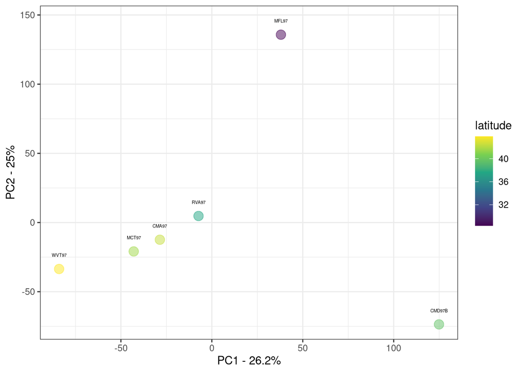

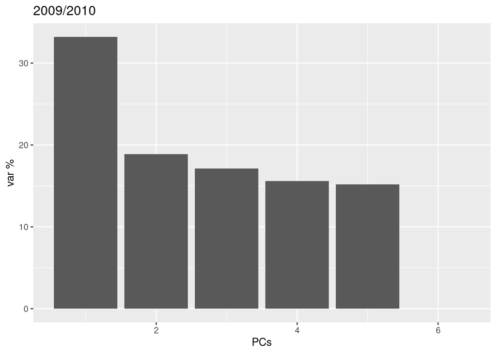

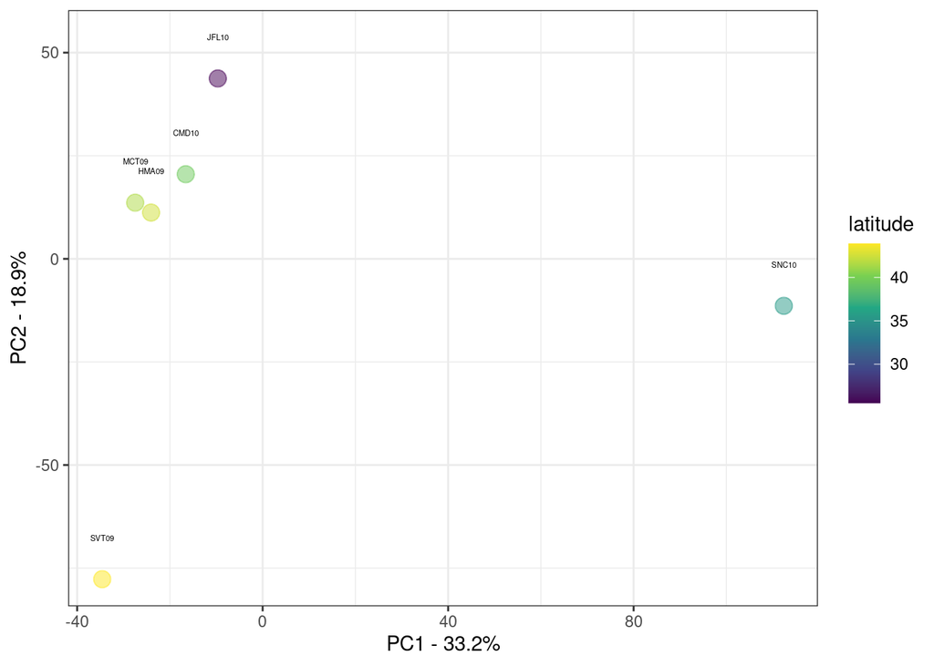

### segundo call

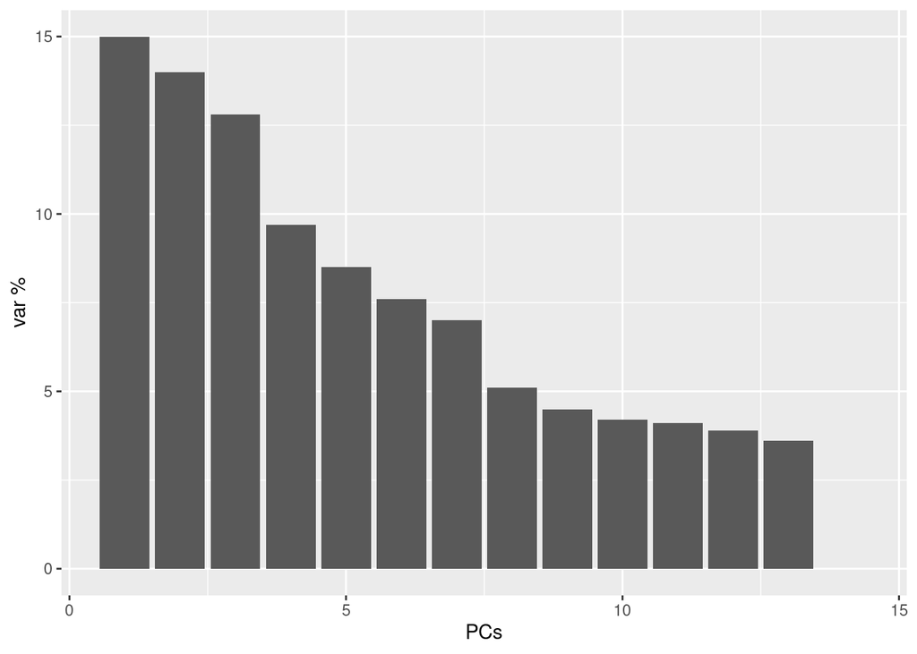

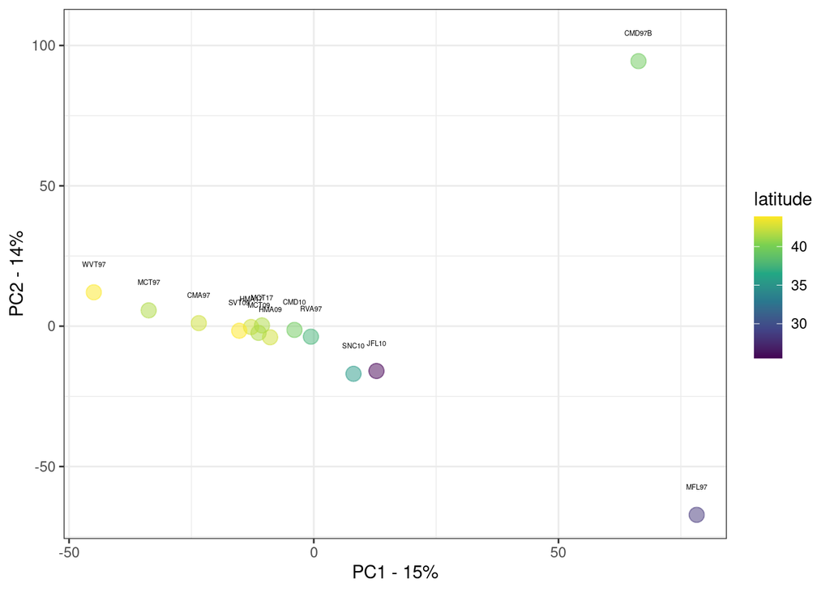

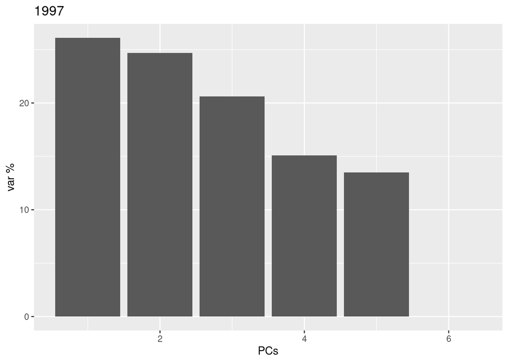

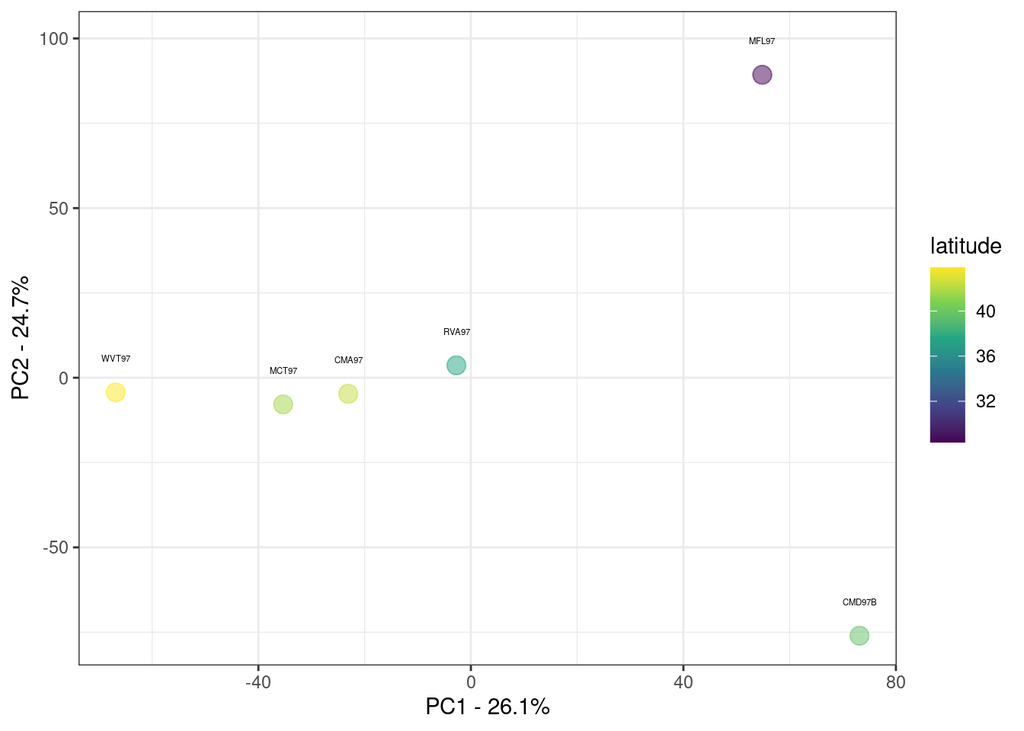

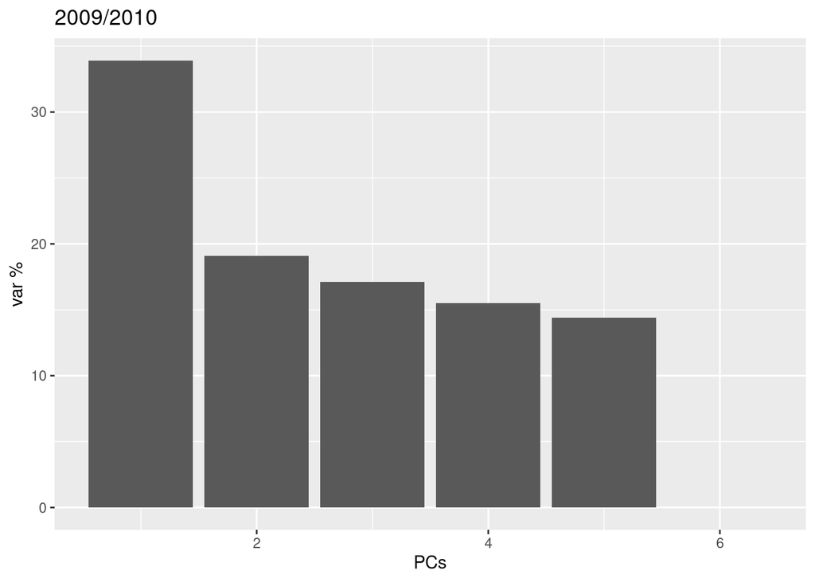

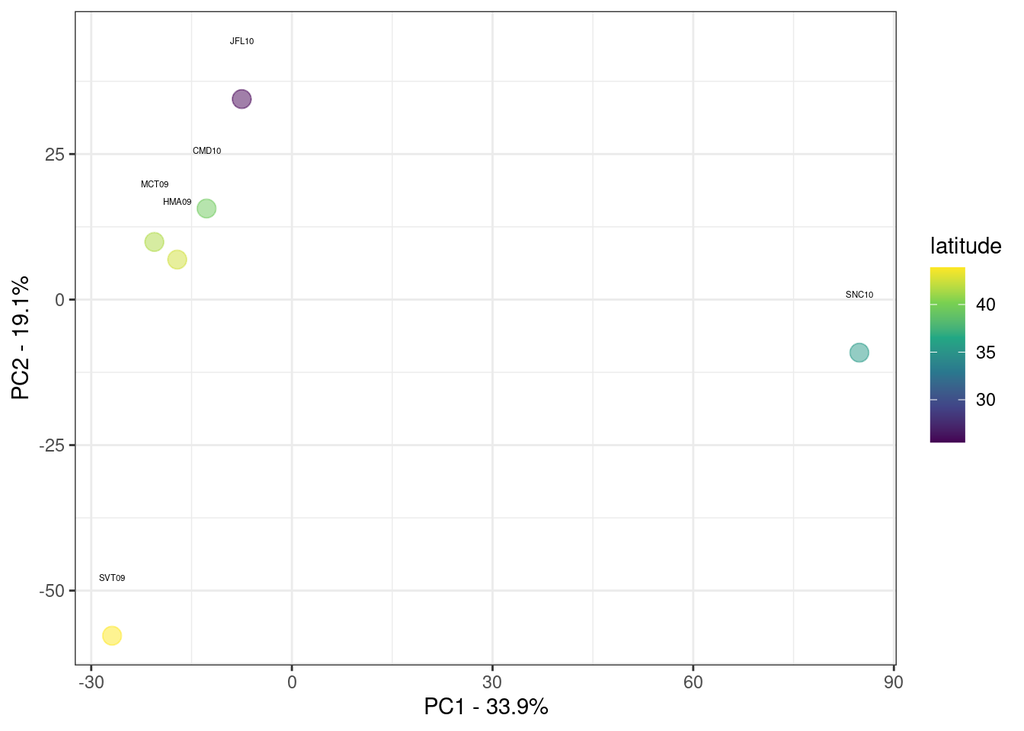